# JMMI Scripts

# Introduction

This (living) document will provide users with a list of scripts useful for conducting basic cleaning and analysis of JMMI data. This is more a repository of code and scripts rather than a full working package. The document is divided into two sections: Cleaning and Analysis.

The second section, analysis, focuses on the calculations needed to compute aggregated median prices (following the median-of-medians methodology), SMEB and MEB aggregations, and trend analysis.

For further inquires or if you would like to have different type of checks included, please reach out to Chris (chris.paci@reach-initiative.org) and/or Alberto (alberto.gualtieri@impact-initiatives.org).

```r
# Load test data
head(data, 3)
```

```
##   uuid enum_id  governorate  district  market item1 item2 item3 item4 item5
## 1  ID1  enum_1 governorate1 district1 market1  3981   100  3655  4323  1311
## 2  ID2  enum_1 governorate1 district1 market2  1407   100  1474  2603   611
## 3  ID3  enum_1 governorate1 district1 market3  4872  2374  3431  4000  3437
##   item6 index
## 1  3345     1
## 2  2373     2
## 3  2503     3
```

# Data Cleaning

### Minimum Standards

The minimum standards function allows you to quickly check how many markets per area of interest have been collected by the enumerators. The function returns a table with the number of market collected aggregated by your variable of interest (it can be district, or governorate).

```r
minium_standards(data, district, market)
```

```
## # A tibble: 26 x 4
## # Groups:   district [12]
##    district   market       n minimum_standards
##    <chr>      <chr>    <int> <chr>
##  1 district1  market1      1 requirement not met
##  2 district1  market2      1 requirement not met
##  3 district1  market3      5 requirement met
##  4 district10 market21     6 requirement met
##  5 district10 market22     1 requirement not met
##  6 district11 market23     3 requirement met
##  7 district11 market24     4 requirement met
##  8 district12 market25     5 requirement met
##  9 district12 market26     7 requirement met
## 10 district2  market4      6 requirement met
## # ... with 16 more rows
```

### Outliers detection

The function that checks for outliers is called “find_outliers”. You can find it inside the “R” folder within the project. The function checks for normal outliers and also log distributed outliers and the output is a table with the outlier value, the index number, and the variable name.

```r
outliers_table <- find_outliers(data)

# Add uuid and location to the output
outliers_table <- outliers_table %>% mutate(uuid= data[.$index,"uuid",drop=T],
                                            area = data[.$index,"district",drop=T])

head(outliers_table, 3)
```

```
##   index value variable has_issue                  issue_type uuid      area
## 1    12 10000    item2      TRUE normal distribution outlier ID12 district2
## 2    33 10000    item2      TRUE normal distribution outlier ID33 district4
## 3    60 10000    item2      TRUE normal distribution outlier ID60 district7
```

### Plotting Item prices using boxplots

The function below will help with visualizing the prices using boxplots. You can find it inside the “R” folder. Box plots visually show the distribution of numerical data and skewness through displaying the data quartiles (or percentiles) and averages.

Hot to read a boxplot: box plots show the five-number summary of a set of data: including the minimum score, first (lower) quartile, median, third (upper) quartile, and maximum score.

If you want to read more about boxplot you can find a guide [here](https://www.simplypsychology.org/boxplots.html)

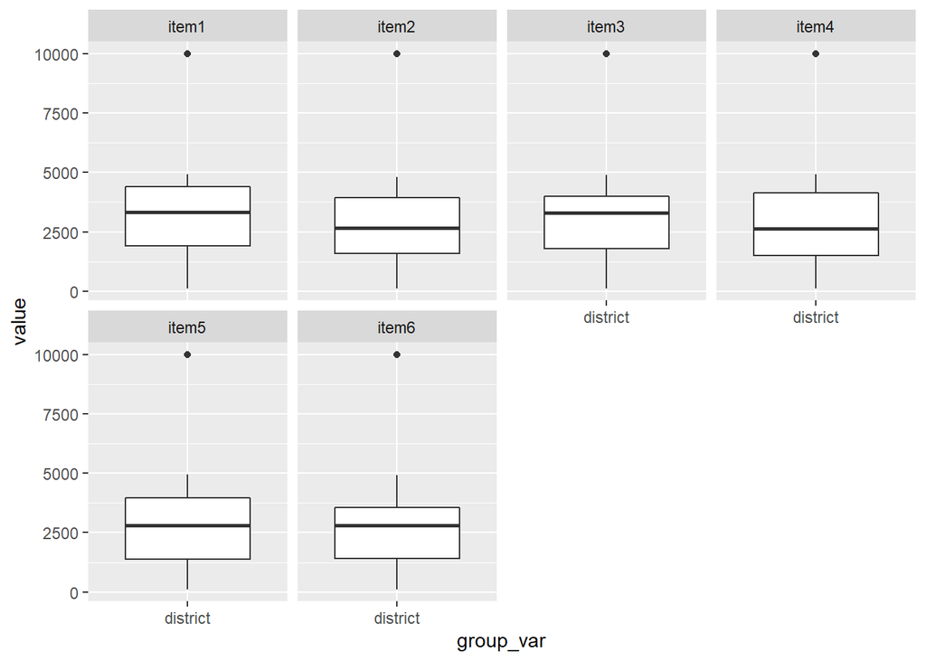

```r
item_boxplots(data, "district", starts_with("item"))
```

### Descriptive statistics

```r
descriptive_stats(data, "district", starts_with("item"))
```

```
## # A tibble: 60 x 8
## # Groups:   district [12]
##    district    item1 item2 item3  item4  item5  item6 stats
##    <chr>       <dbl> <dbl> <dbl>  <dbl>  <dbl>  <dbl> <chr>
##  1 district1   1407   100  1474    100    584    100  min
##  2 district1   2705   383  1802.   836.   961   1682  Q1
##  3 district1   3916.  765  1868   2013   3437   2373  median
##  4 district1   4872  1580. 3050.  3302.  4034.  2897  Q3
##  5 district1  10000  2813  3655   4323  10000   3345  max
##  6 district10   100   100  1671    950   2138    100  min
##  7 district10  1244. 2010  2728.  1705   2564.  1190. Q1
##  8 district10  3705  2975  3770   2651   2780   2655  median
##  9 district10  4790. 4176. 4114.  4162   3344.  4370. Q3
## 10 district10 10000  4675  4492  10000   3650  10000  max
## # ... with 50 more rows
```

### Falsification test / Silhouette Analysis

A “Silhouette Analysis” is based on the “gower” distance between surveys which is a metric that measures the dissimilarities between two items with mixed numeric and non-numeric data. This method checks for anomalies assuming the datast is clustered around the enumerator ID. A silhouette value of 1 indicates that the entries of the cluster are very similar to each other, while a value close to 0 or negative indicates the opposite. Values close to 1 should raise a flag as it means that enumerators are filling surveys very similar to one another.

For more information on this type of falsification test you can read here, and [here](https://medium.com/@rumman1988/clustering-categorical-and-numerical-datatype-using-gower-distance-ab89b3aa90d9).

```r
# To run the function you will need the dataset, the kobo tool, the enumerator_id or enumerator_name colun, and and admin column

calculateEnumeratorSimilarity(data, tool, "enum_id", "governorate")
```

```
##                 governorate enum_id num.surveys        si
## governorate1.1 governorate1  enum_2           6 0.4217888
## governorate1.2 governorate1  enum_3          11 0.3581966
## governorate1.3 governorate1  enum_1           7 0.2956391
## governorate2.1 governorate2  enum_5          14 0.3867257
## governorate2.2 governorate2  enum_4          11 0.3838637
## governorate3.1 governorate3  enum_6           8 0.4094005
## governorate3.2 governorate3  enum_7           7 0.2490363
## governorate3.3 governorate3  enum_8           7 0.2239891
## governorate4.1 governorate4  enum_2          12 0.3954538
## governorate4.2 governorate4  enum_0           7 0.3309172
## governorate4.3 governorate4  enum_1           7 0.2279400
```

# Data Analysis

### Median aggregation

The first step to calculate the SMEB value is to aggregate prices using the median-of-medians methodology. This methodology ensures a balanced aggregation reducing the variance created by having markets largely more surveyed compared to others.

```r
# Aggregation by governorate, district, and market
median_items <- data %>%
                select(-uuid, -enum_id, -index) %>%                             # select only the items and aggregation columns
                group_by(governorate, district, market) %>%                     # group by what you want
                summarise_all(funs(median(., na.rm = TRUE)))                    # aggregate by median

print(head(median_items, 3))
```

```
## # A tibble: 3 x 9
## # Groups:   governorate, district [1]
##   governorate  district  market  item1 item2 item3 item4 item5 item6
##   <chr>        <chr>     <chr>   <dbl> <dbl> <dbl> <dbl> <dbl> <dbl>
## 1 governorate1 district1 market1  3981   100  3655  4323  1311  3345
## 2 governorate1 district1 market2  1407   100  1474  2603   611  2373
## 3 governorate1 district1 market3  4362   787  1868  1156  3735  2028
```

```r
# Aggregation by governorate and district
median_items_district <- data %>%
                        select(-uuid, -enum_id, -index, -market) %>% group_by(governorate, district) %>%
                        summarise_all(funs(median(., na.rm = TRUE)))

print(head(median_items_district, 3))
```

```
## # A tibble: 3 x 8
## # Groups:   governorate [1]
##   governorate  district  item1 item2 item3 item4 item5 item6
##   <chr>        <chr>     <dbl> <dbl> <dbl> <dbl> <dbl> <dbl>
## 1 governorate1 district1 3916.   765  1868 2013  3437  2373
## 2 governorate1 district2 3512.  2479  1909 3940  2740. 1847
## 3 governorate1 district3 2932.  3094  3670 1916. 1640  2530.
```

### SMEB calculation

Below we show a few lines of code you can use to quickly calculate the SMEB value after having calculated the median price per item. The calculation will be different based on the weights and the items included in the SMEB. If you nee to split the calculation across multiple SMEBs you can split the code.

```r
# This piece of code will calculate the smeb value for each item

smeb <- median_items_district %>% group_by(district) %>%          # the group_by can be changed based on the aggregation level you desire
                                  mutate(
                                  smeb_item1 = item1 * 0.5,
                                  smeb_item2 = item2 * 0.5,
                                  smeb_item3 = item3 * 0.5,
                                  smeb_item4 = item4 * 0.5,
                                  smeb_item5 = item5 * 0.5,
                                  smeb_item6 = item6 * 0.5
                                  )

print(head(smeb, 3))
```

```
## # A tibble: 3 x 14
## # Groups:   district [3]
##   governorate district item1 item2 item3 item4 item5 item6 smeb_item1 smeb_item2
##   <chr>       <chr>    <dbl> <dbl> <dbl> <dbl> <dbl> <dbl>      <dbl>      <dbl>
## 1 governorat~ distric~ 3916.   765  1868 2013  3437  2373       1958.       382.
## 2 governorat~ distric~ 3512.  2479  1909 3940  2740. 1847       1756.      1240.
## 3 governorat~ distric~ 2932.  3094  3670 1916. 1640  2530.      1466.      1547
## # ... with 4 more variables: smeb_item3 <dbl>, smeb_item4 <dbl>,
## #   smeb_item5 <dbl>, smeb_item6 <dbl>
```

```r
# If NAs are present the following code will input the median value of the district of govenorate of choice to fill the blank
smeb_no_NAs <- smeb %>% group_by(district) %>%  # the group_by can be changed based on what median value you want to input
                        mutate(
                              smeb_item1= ifelse(is.na(smeb_item1), median(smeb_item1, na.rm=T), smeb_item1),
                              smeb_item2= ifelse(is.na(smeb_item2), median(smeb_item2, na.rm=T), smeb_item2),
                              smeb_item3= ifelse(is.na(smeb_item3), median(smeb_item3, na.rm=T), smeb_item3),
                              smeb_item4= ifelse(is.na(smeb_item4), median(smeb_item4, na.rm=T), smeb_item4),
                              smeb_item5= ifelse(is.na(smeb_item5), median(smeb_item5, na.rm=T), smeb_item5),
                              smeb_item6= ifelse(is.na(smeb_item6), median(smeb_item6, na.rm=T), smeb_item6)
                              ) %>% select(governorate, district, starts_with("smeb"))

print(head(smeb_no_NAs, 3))
```

```
## # A tibble: 3 x 8
## # Groups:   district [3]
##   governorate district smeb_item1 smeb_item2 smeb_item3 smeb_item4 smeb_item5
##   <chr>       <chr>         <dbl>      <dbl>      <dbl>      <dbl>      <dbl>
## 1 governorat~ distric~      1958.       382.       934       1006.      1718.
## 2 governorat~ distric~      1756.      1240.       954.      1970       1370.
## 3 governorat~ distric~      1466.      1547       1835        958.       820
## # ... with 1 more variable: smeb_item6 <dbl>
```

### Trend analysis

```r
# After loading the datset from two consecutive months, we rbind them together
data2 <- rbind(month1, month2)

# We aggregate the median dataset to the desired level (district in this case)
median_items_district <- data2 %>%
                         select(-uuid, -enum_id, -index, -market) %>% group_by(month, governorate, district) %>%
                         summarise_all(funs(median(., na.rm = TRUE)))

# Calculate the smeb
smeb <- median_items_district %>% group_by(district) %>%
                                  mutate(
                                  smeb_item1 = item1 * 0.5,
                                  smeb_item2 = item2 * 0.5,
                                  smeb_item3 = item3 * 0.5,
                                  smeb_item4 = item4 * 0.5,
                                  smeb_item5 = item5 * 0.5,
                                  smeb_item6 = item6 * 0.5
                                  )

# Create the comparison column
smeb$month_date<- lubridate::month(smeb$month)

# Run the percentag change formula taken from the butteR package
pct_change <- smeb %>% pct_change_by_groups_all_numerics(group_var = "district", time_id = "month_date")

print(head(pct_change, 3))
```

```
## # A tibble: 3 x 13
## # Groups:   district [3]
##   district item1 item2 item3 item4  item5 item6 smeb_item1 smeb_item2 smeb_item3
##   <chr>    <dbl> <dbl> <dbl> <dbl>  <dbl> <dbl>      <dbl>      <dbl>      <dbl>
## 1 distric~ 56.7  360.  122.  115.    7.80  54.3      56.7       360.       122.
## 2 distric~  2.27 -55.2  30.4 124.   46.6   70.9       2.27      -55.2       30.4
## 3 distric~ 61.1   11.6  44.3  51.0 -13.4  -28.1      61.1        11.6       44.3
## # ... with 3 more variables: smeb_item4 <dbl>, smeb_item5 <dbl>,
## #   smeb_item6 <dbl>
```